# Motor Cars

MT

12/18/2020

Qns 1. “Is an automatic or manual transmission better for MPG” 2. “Quantify the MPG difference between automatic and manual transmissions”

Criteria / R Markdown - 2 pages longs but no longer than 5 with supporting appendix of figures / Included executive summary - Exploratory data analysis - Interpretation of coef - Fit multiple models and reasons for the model selection - Residual plot for diagnostic - Quantify uncertainty in conclusion and/or perform inference correctly - Answering of the questions of interest

# Exploring Dataset

```r
library(datasets)
data(mtcars)
head(mtcars)
```

```
##                    mpg cyl disp  hp drat    wt  qsec vs am gear carb
## Mazda RX4         21.0   6  160 110 3.90 2.620 16.46  0  1    4    4
## Mazda RX4 Wag     21.0   6  160 110 3.90 2.875 17.02  0  1    4    4
## Datsun 710        22.8   4  108  93 3.85 2.320 18.61  1  1    4    1
## Hornet 4 Drive    21.4   6  258 110 3.08 3.215 19.44  1  0    3    1
## Hornet Sportabout 18.7   8  360 175 3.15 3.440 17.02  0  0    3    2
## Valiant           18.1   6  225 105 2.76 3.460 20.22  1  0    3    1
```

```r
summary(mtcars)
```

```
##       mpg             cyl             disp             hp
##  Min.   :10.40   Min.   :4.000   Min.   : 71.1   Min.   : 52.0
##  1st Qu.:15.43   1st Qu.:4.000   1st Qu.:120.8   1st Qu.: 96.5
##  Median :19.20   Median :6.000   Median :196.3   Median :123.0
##  Mean   :20.09   Mean   :6.188   Mean   :230.7   Mean   :146.7
##  3rd Qu.:22.80   3rd Qu.:8.000   3rd Qu.:326.0   3rd Qu.:180.0
##  Max.   :33.90   Max.   :8.000   Max.   :472.0   Max.   :335.0
##       drat             wt             qsec             vs
##  Min.   :2.760   Min.   :1.513   Min.   :14.50   Min.   :0.0000
##  1st Qu.:3.080   1st Qu.:2.581   1st Qu.:16.89   1st Qu.:0.0000
##  Median :3.695   Median :3.325   Median :17.71   Median :0.0000
##  Mean   :3.597   Mean   :3.217   Mean   :17.85   Mean   :0.4375
##  3rd Qu.:3.920   3rd Qu.:3.610   3rd Qu.:18.90   3rd Qu.:1.0000
##  Max.   :4.930   Max.   :5.424   Max.   :22.90   Max.   :1.0000
##        am              gear            carb
##  Min.   :0.0000   Min.   :3.000   Min.   :1.000
##  1st Qu.:0.0000   1st Qu.:3.000   1st Qu.:2.000
##  Median :0.0000   Median :4.000   Median :2.000
##  Mean   :0.4062   Mean   :3.688   Mean   :2.812
##  3rd Qu.:1.0000   3rd Qu.:4.000   3rd Qu.:4.000
##  Max.   :1.0000   Max.   :5.000   Max.   :8.000
```

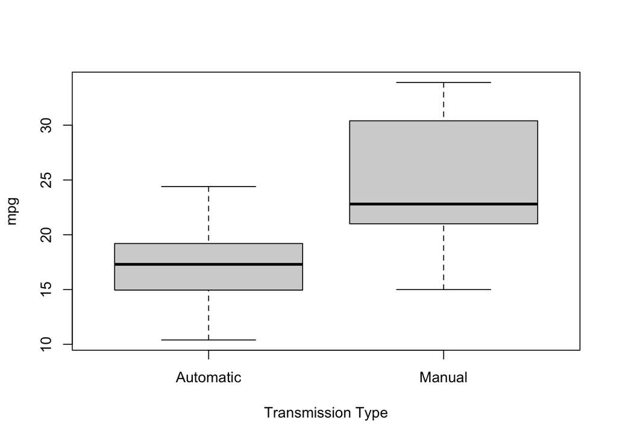

```r
mtcars$cyl <- factor(mtcars$cyl)
mtcars$vs <- factor(mtcars$vs)
mtcars$gear <- factor(mtcars$gear)
mtcars$carb <- factor(mtcars$carb)
mtcars$am <- factor(mtcars$am,labels=c('Automatic','Manual'))
boxplot(mpg~am, mtcars, xlab="Transmission Type")
```

Based on the boxplot, it can be observes that there might be a significant difference in MPG for the different transmission.

#Simple linear Regression Model

```r
mpgam<- lm(mpg~factor(am), mtcars)
summary(mpgam)
```

```
##
## Call:
## lm(formula = mpg ~ factor(am), data = mtcars)
##
## Residuals:
##     Min      1Q  Median      3Q     Max
## -9.3923 -3.0923 -0.2974  3.2439  9.5077
##
## Coefficients:
##                  Estimate Std. Error t value Pr(>|t|)
## (Intercept)        17.147      1.125  15.247 1.13e-15 ***
## factor(am)Manual    7.245      1.764   4.106 0.000285 ***
## ---
## Signif. codes:  0 '***' 0.001 '**' 0.01 '*' 0.05 '.' 0.1 ' ' 1
##
## Residual standard error: 4.902 on 30 degrees of freedom
## Multiple R-squared:  0.3598, Adjusted R-squared:  0.3385
## F-statistic: 16.86 on 1 and 30 DF,  p-value: 0.000285
```

Looking at the single variate model, the R^2 values were only 0.3598. Which also means that only 35.9% of variance can be explained by this model and does not provide a good fit to the dataset observed. Hence, other predictors are to be further assessed for any influence to create a better fit of model.

#Multivariate Regression Model

```r
mpgam_all<- lm(mpg~., mtcars)
summary(mpgam_all)
```

```
##
## Call:
## lm(formula = mpg ~ ., data = mtcars)
##
## Residuals:
##     Min      1Q  Median      3Q     Max
## -3.5087 -1.3584 -0.0948  0.7745  4.6251
##
## Coefficients:
##             Estimate Std. Error t value Pr(>|t|)
## (Intercept) 23.87913   20.06582   1.190   0.2525
## cyl6        -2.64870    3.04089  -0.871   0.3975
## cyl8        -0.33616    7.15954  -0.047   0.9632
## disp         0.03555    0.03190   1.114   0.2827
## hp          -0.07051    0.03943  -1.788   0.0939 .
## drat         1.18283    2.48348   0.476   0.6407
## wt          -4.52978    2.53875  -1.784   0.0946 .
## qsec         0.36784    0.93540   0.393   0.6997
## vs1          1.93085    2.87126   0.672   0.5115
## amManual     1.21212    3.21355   0.377   0.7113
## gear4        1.11435    3.79952   0.293   0.7733
## gear5        2.52840    3.73636   0.677   0.5089
## carb2       -0.97935    2.31797  -0.423   0.6787
## carb3        2.99964    4.29355   0.699   0.4955
## carb4        1.09142    4.44962   0.245   0.8096
## carb6        4.47757    6.38406   0.701   0.4938
## carb8        7.25041    8.36057   0.867   0.3995
## ---
## Signif. codes:  0 '***' 0.001 '**' 0.01 '*' 0.05 '.' 0.1 ' ' 1
##
## Residual standard error: 2.833 on 15 degrees of freedom
## Multiple R-squared:  0.8931, Adjusted R-squared:  0.779
## F-statistic:  7.83 on 16 and 15 DF,  p-value: 0.000124
```

```r
mpgam_cor<- lm(mpg~am+cyl+disp+hp+wt, mtcars)
mpgam_cor_nowt<- lm(mpg~am+cyl+hp+disp, mtcars)
mpgam_cor_noam<- lm(mpg~cyl+hp+disp, mtcars)
mpgam_cor_nodisp<- lm(mpg~am+cyl+hp+wt, data=mtcars)
mpgam_cor_noamdisp<- lm(mpg~cyl+hp+wt, data=mtcars)
anova(mpgam_all,
      mpgam_cor,
      mpgam_cor_nowt,
      mpgam_cor_noam,
      mpgam_cor_nodisp,
      mpgam_cor_noamdisp)
```

```
## Analysis of Variance Table
##
## Model 1: mpg ~ cyl + disp + hp + drat + wt + qsec + vs + am + gear + carb
## Model 2: mpg ~ am + cyl + disp + hp + wt
## Model 3: mpg ~ am + cyl + hp + disp
## Model 4: mpg ~ cyl + hp + disp
## Model 5: mpg ~ am + cyl + hp + wt
## Model 6: mpg ~ cyl + hp + wt
##   Res.Df    RSS  Df Sum of Sq      F   Pr(>F)
## 1     15 120.40
## 2     25 150.41 -10   -30.006 0.3738 0.939655
## 3     26 183.04  -1   -32.630 4.0652 0.062050 .
## 4     27 225.12  -1   -42.078 5.2422 0.036960 *
## 5     26 151.03   1    74.092 9.2305 0.008301 **
## 6     27 160.78  -1    -9.752 1.2149 0.287730
## ---
## Signif. codes:  0 '***' 0.001 '**' 0.01 '*' 0.05 '.' 0.1 ' ' 1
```

```r
step(mpgam_all,direction = "both")
```

```
## Start:  AIC=76.4
## mpg ~ cyl + disp + hp + drat + wt + qsec + vs + am + gear + carb
##
##        Df Sum of Sq    RSS    AIC
## - carb  5   13.5989 134.00 69.828
## - gear  2    3.9729 124.38 73.442
## - am    1    1.1420 121.55 74.705
## - qsec  1    1.2413 121.64 74.732
## - drat  1    1.8208 122.22 74.884
## - cyl   2   10.9314 131.33 75.184
## - vs    1    3.6299 124.03 75.354
## <none>              120.40 76.403
## - disp  1    9.9672 130.37 76.948
## - wt    1   25.5541 145.96 80.562
## - hp    1   25.6715 146.07 80.588
##
## Step:  AIC=69.83
## mpg ~ cyl + disp + hp + drat + wt + qsec + vs + am + gear
##
##        Df Sum of Sq    RSS    AIC
## - gear  2    5.0215 139.02 67.005
## - disp  1    0.9934 135.00 68.064
## - drat  1    1.1854 135.19 68.110
## - vs    1    3.6763 137.68 68.694
## - cyl   2   12.5642 146.57 68.696
## - qsec  1    5.2634 139.26 69.061
## <none>              134.00 69.828
## - am    1   11.9255 145.93 70.556
## - wt    1   19.7963 153.80 72.237
## - hp    1   22.7935 156.79 72.855
## + carb  5   13.5989 120.40 76.403
##
## Step:  AIC=67
## mpg ~ cyl + disp + hp + drat + wt + qsec + vs + am
##
##        Df Sum of Sq    RSS    AIC
## - drat  1    0.9672 139.99 65.227
## - cyl   2   10.4247 149.45 65.319
## - disp  1    1.5483 140.57 65.359
## - vs    1    2.1829 141.21 65.503
```

[output cut: 56 more lines]

```
## Step:  AIC=61.65
## mpg ~ cyl + hp + wt + am
##
##        Df Sum of Sq    RSS    AIC
## <none>              151.03 61.655
## - am    1     9.752 160.78 61.657
## + vs    1     7.346 143.68 62.059
## + qsec  1     7.044 143.98 62.126
## - cyl   2    29.265 180.29 63.323
## + disp  1     0.617 150.41 63.524
## + drat  1     0.220 150.81 63.608
## + gear  2     1.361 149.66 65.365
## - hp    1    31.943 182.97 65.794
## - wt    1    46.173 197.20 68.191
## + carb  5     5.633 145.39 70.438
```

```
##
## Call:
## lm(formula = mpg ~ cyl + hp + wt + am, data = mtcars)
##
## Coefficients:
## (Intercept)         cyl6         cyl8           hp           wt     amManual
##    33.70832     -3.03134     -2.16368     -0.03211     -2.49683      1.80921
```

#Analysis and Conclusion ##Inference

```r
summary (mpgam_cor_nodisp)
```

```
##
## Call:
## lm(formula = mpg ~ am + cyl + hp + wt, data = mtcars)
##
## Residuals:
##     Min      1Q  Median      3Q     Max
## -3.9387 -1.2560 -0.4013  1.1253  5.0513
##
## Coefficients:
##             Estimate Std. Error t value Pr(>|t|)
## (Intercept) 33.70832    2.60489  12.940 7.73e-13 ***
## amManual     1.80921    1.39630   1.296  0.20646
## cyl6        -3.03134    1.40728  -2.154  0.04068 *
## cyl8        -2.16368    2.28425  -0.947  0.35225
## hp          -0.03211    0.01369  -2.345  0.02693 *
## wt          -2.49683    0.88559  -2.819  0.00908 **
## ---
## Signif. codes:  0 '***' 0.001 '**' 0.01 '*' 0.05 '.' 0.1 ' ' 1
##
## Residual standard error: 2.41 on 26 degrees of freedom
## Multiple R-squared:  0.8659, Adjusted R-squared:  0.8401
## F-statistic: 33.57 on 5 and 26 DF,  p-value: 1.506e-10
```

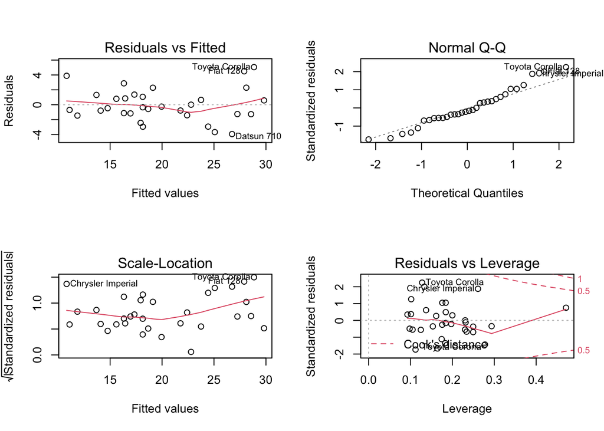

```r
par(mfrow = c(2, 2))
plot(mpgam_cor_nodisp)
```

```r
t.test(mpg ~ am, data = mtcars)
```

```
##
##  Welch Two Sample t-test
##
## data:  mpg by am
## t = -3.7671, df = 18.332, p-value = 0.001374
## alternative hypothesis: true difference in means is not equal to 0
## 95 percent confidence interval:
##  -11.280194  -3.209684
## sample estimates:
## mean in group Automatic    mean in group Manual
##                17.14737                24.39231
```

Basing on the summary, the adjusted R^2 suggests that the predicted model is able to conclude 84% of the variability. T-Test also shows shows that automatic and manual are significantly different from each other.

The points in residuals vs.Fitted plots seem to be randomly scattered on showing that it is independent. The normal Q-Q plot consist of points which closely fits the line indicating that they are normal. The scale-location plot are scattered constantly, indicating constant variance. The leverage plots, showed that there are some points which may potentially have some strong influences. ## Leverage Diagnosis

```r
lev<- hatvalues(mpgam_cor_nodisp)
tail(sort(lev),3)
```

```
##       Toyota Corona Lincoln Continental       Maserati Bora
##           0.2777872           0.2936819           0.4713671
```

```r
tail(sort(dfbeta(mpgam_cor_nodisp)[,1]),3)
```

```
## Cadillac Fleetwood     Toyota Corolla         Volvo 142E
##          0.7309046          0.8005292          0.8247396
```

```r
dfbeta(mpgam_cor_nodisp)
```

[output not shown]

[output cut: 11 more lines]

```
## Fiat 128            -4.850859e-03  0.1761795500
## Honda Civic         -6.994888e-04 -0.0249656283
## Toyota Corolla      -4.217764e-03 -0.0848126418
## Toyota Corona       -6.343905e-03  0.3157351129
## Dodge Challenger     4.014083e-03  0.1299759787
## AMC Javelin          4.705755e-03  0.2003492713
## Camaro Z28          -1.397573e-03  0.0588984440
## Pontiac Firebird    -2.447704e-03 -0.0528466059
## Fiat X1-9            1.102357e-03  0.0026055127
## Porsche 914-2        1.248995e-04 -0.0132548434
## Lotus Europa         2.866525e-03 -0.2488655771
## Ford Pantera L      -1.332751e-03  0.0589404394
## Ferrari Dino        -3.186537e-04  0.0029006386
## Maserati Bora        7.252169e-03 -0.0787658687
## Volvo 142E          -3.157628e-04 -0.3699212040
```

#Appendix

```r
library(GGally)
```

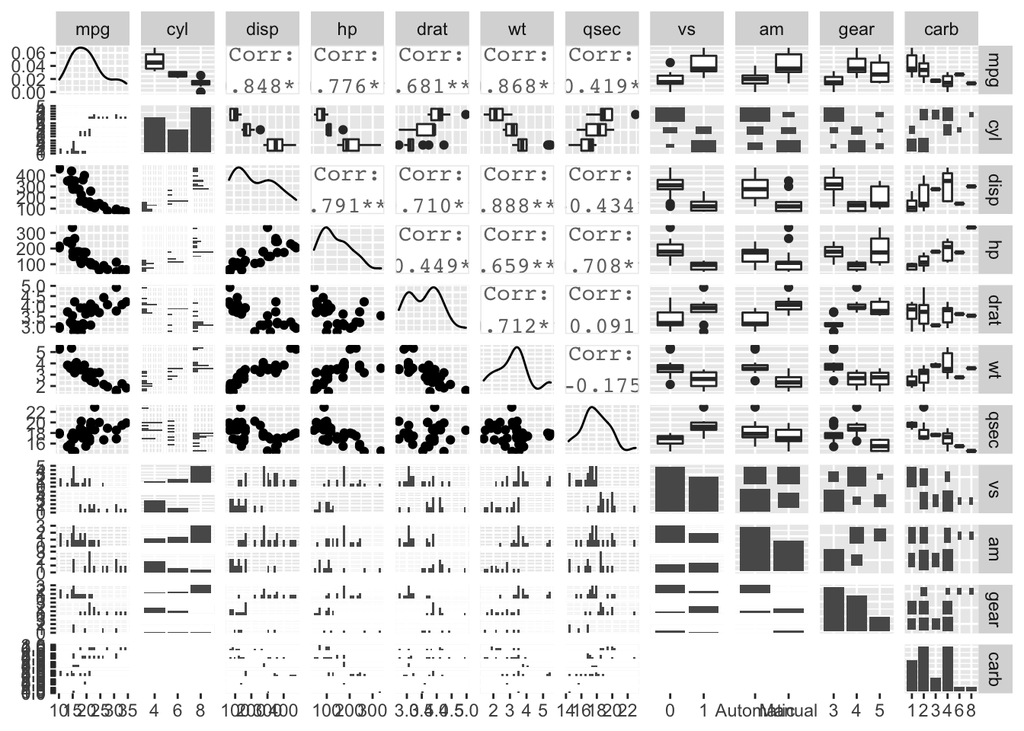

```r
library(ggplot2)
ggpairs(mtcars)
```

Plots showing the correlation between two variables, distribution and the scatterplots. The plot provides a quick exploratory analysis to identify the plots of interest.